# Rural-Urban Disparities in Hemoglobin Level among Pregnant Women in Nigeria

Findings from the 2018 Demographic and Health Survey

Christian Duru

2023-12-16

## Introduction

Hemoglobin plays a vital role during pregnancy as it is a protein responsible for carrying oxygen from the lungs to the rest of the body and transporting carbon dioxide back to the lungs for exhalation. During pregnancy, the demand for oxygen increases due to the growing fetus and the changes in the mother’s body. The dataset in this project presents findings from the 2018 Health and Demographic Survey on the disparities of hemoglobin level among pregnant women aged 15 - 49 years across different regions in Nigeria.

## Demographic Information

The demographic information of pregnant women used in this project include: `age`, `education level`, `geopolitical region`, and `residential area`. These variables were used to contextualize the disparities in social determinants of health and its correlation with hemoglobin level (g/dl) among pregnant women. Below is a brief data summary of the total number of women (n = 4191) and percentage of pregnant women residing in urban and rural areas (33% vs 67%), followed by a graphical representation of their education level.

### Data summary of pregnant women

| Residential Area | n | Pregnant women | Percentage |
| --- | --- | --- | --- |
| Urban | 4191 | 1371 | 33% |
| Rural | 4191 | 2820 | 67% |

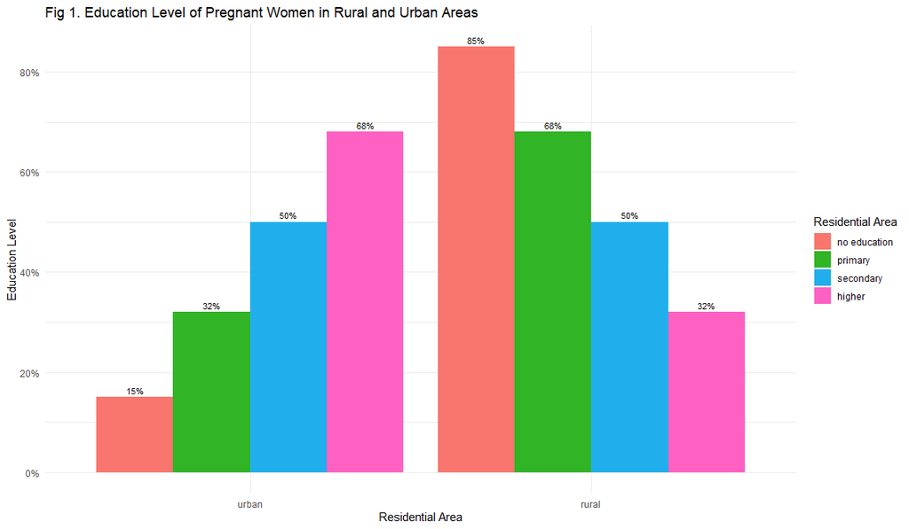

## Descriptive statistics of variables

The descriptive statistics provides a clear overview of the measures of central tendency, including the `mean age)` and `mean hemoglobin_level` in rural and urban areas.In addition, the line graph and scatter plots below shows the distribution of hemoglobin (g/dl) among pregnant women in relation to altitude (m) and duration of pregnancy.

### Mean data of variables

| Residential Area | Mean Age | Mean Hemoglobin |
| --- | --- | --- |
| Urban | 28.35 | 67.44 |
| Rural | 27.03 | 64.24 |

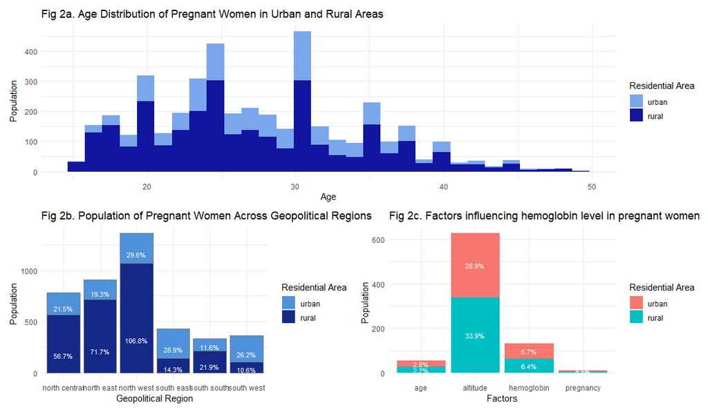

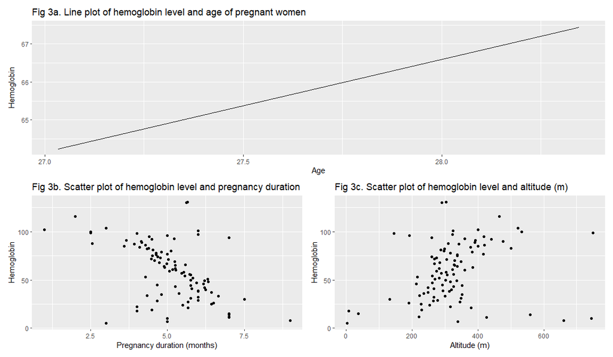

## Box plot visualization

The box plot here shows a graphical representation of the distribution of hemoglobin in rural and urban areas. It provides a summary of the central tendency, spread, and skewness of the data.

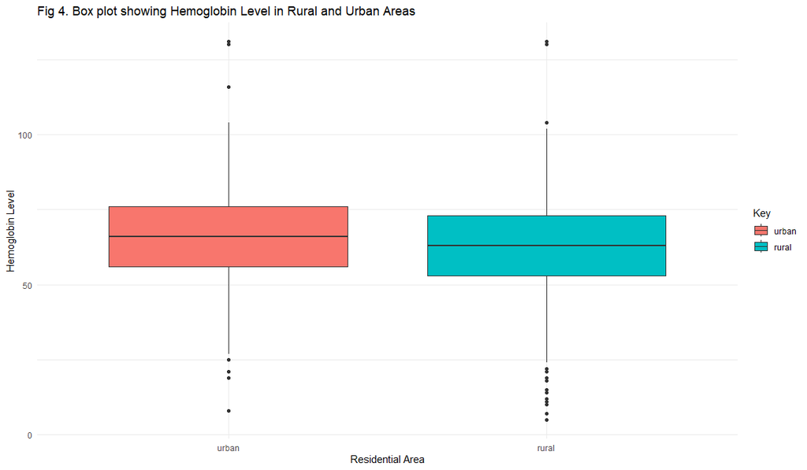